# R Notebook

```r
library(tidyverse)
library(lubridate)
library(dplyr)
library(ggplot2)
```

Introduction: Airbnb, more than just a vacation rental company, was one of the market disruptors that started in 2008 which destabilized the hotel industry and changed the way people traveled by offering more options in booking places to stay. It got so popular that more and more people started using it as a business which eventually led to certain cities to put in place regulations on short term rentals.  
Data: One of those cities is Washington, D.C and I obtained my data from insideairbnb.com, an independent non-commercial project that gathers publicly available Airbnb information with the express purpose of promoting awareness on this issue of Airbnb adversely affecting local neighborhoods and established real-estate businesses. The dataset only provided listings that were available for the last 12 months in Washington, D.C.  
Objective: With that in mind, through this project I wanted to explore 2 questions particularly in the current post Covid state: 1) As a potential guest, where are the more affordable yet well rated and reviewed listings? 2) As a potential host, which area has the most demand and likelihood of occupancy in the D.C market for listings?

The main data I will be working with is the listings data and it includes all kinds of data from which I selected data regarding the following:listings, coordinate location, neighborhood, price per night, room type, number of reviews, review scores, and availability days per year.

Read in the data:

```r
listings = read.csv('./listings.csv')
listings_detailed = read.csv('./listings_detailed.csv')
head(listings)
```

|  | id | name | host_id | host_name | neighbourhood_group | neighbourhood | latitude | longitude | room_type | price | minimum_nights | number_of_reviews | last_review | reviews_per_month | calculated_host_listings_count | availability_365 |
| --- | --- | --- | --- | --- | --- | --- | --- | --- | --- | --- | --- | --- | --- | --- | --- | --- |
| 1 | 3686 | Vita's Hideaway | 4645 | Vita | NA | Historic Anacostia | 38.86339 | -76.98889 | Private room | 55 | 2 | 75 | 1/12/2021 | 0.59 | 2 | 363 |
| 2 | 3943 | Historic Rowhouse Near Monuments | 5059 | Vasa | NA | Edgewood, Bloomingdale, Truxton Circle, Eckington | 38.91195 | -77.00456 | Private room | 70 | 2 | 429 | 8/7/2018 | 2.95 | 2 | 365 |
| 3 | 4197 | Bedroom in DC 2 blocks to Metro | 5061 | Sandra | NA | Capitol Hill, Lincoln Park | 38.88719 | -76.99472 | Private room | 80 | 28 | 45 | 3/14/2020 | 0.31 | 2 | 324 |
| 4 | 4529 | Bertina's House Part One | 5803 |  | NA | Eastland Gardens, Kenilworth | 38.90585 | -76.94469 | Private room | 54 | 30 | 102 | 7/5/2019 | 0.72 | 1 | 140 |
| 5 | 4967 | DC, Near Metro | 7086 | Seveer | NA | Ivy City, Arboretum, Trinidad, Carver Langston | 38.91217 | -76.99249 | Private room | 99 | 2 | 31 | 9/22/2016 | 0.24 | 3 | 295 |
| 6 | 5589 | Cozy apt in Adams Morgan | 6527 | Ami | NA | Kalorama Heights, Adams Morgan, Lanier Heights | 38.91887 | -77.04008 | Entire home/apt | 73 | 3 | 95 | 3/5/2020 | 0.67 | 2 | 123 |

```r
head(listings_detailed)
```

|  | id | listing_url | scrape_id | last_scraped | name | description | neighborhood_overview | picture_url | host_id | host_url | host_name | host_since | host_location | host_about | host_response_time | host_response_rate | host_acceptance_rate | host_is_superhost | host_thumbnail_url | host_picture_url | host_neighbourhood | host_listings_count | host_total_listings_count | host_verifications | host_has_profile_pic | host_identity_verified | neighbourhood | neighbourhood_cleansed | neighbourhood_group_cleansed | … |
| --- | --- | --- | --- | --- | --- | --- | --- | --- | --- | --- | --- | --- | --- | --- | --- | --- | --- | --- | --- | --- | --- | --- | --- | --- | --- | --- | --- | --- | --- | --- |
| 1 | 3686 | https://www.airbnb.com/rooms/3686 | 2.021042e+13 | 2021-04-22 | Vita's Hideaway | IMPORTANT NOTES* Carefully read and be sure that you understand the cancellation policy outlined for this listing. Call airbnb for clarification BEFORE you make a reservation. You can lose money for a… | We love that our neighborhood is up and coming. New restaurants, art galleries, a playhouse, and renovated homes are popping up right before our eyes. | https://a0.muscache.com/pictures/61e02c7e-3d66-466a-b740-8f3e29494f88.jpg | 4645 | https://www.airbnb.com/users/show/4645 | Vita | 2008-11-26 | Washington D.C., District of Columbia, United States | I am a literary scholar, teacher, poet, vegan chef, and, most important, mother of two beautiful, athletic, and artistic children, who is looking to host good-hearted, adventurous, and open-minded peo… | a few days or more | 0% | 80% | f | https://a0.muscache.com/im/users/4645/profile_pic/1353648671/original.jpg?aki_policy=profile_small | https://a0.muscache.com/im/users/4645/profile_pic/1353648671/original.jpg?aki_policy=profile_x_medium | Anacostia | 2 | 2 | ['email', 'phone', 'reviews', 'jumio', 'offline_government_id', 'government_id', 'work_email'] | t | t | Washington, District of Columbia, United States | Historic Anacostia | NA | … |
| 2 | 3943 | https://www.airbnb.com/rooms/3943 | 2.021042e+13 | 2021-04-25 | Historic Rowhouse Near Monuments | Please contact us before booking to make sure we are available to host you.Guest room in our historic 1900 Victorian rowhouse. Home is in the middle of a beautiful, tree-lined, well-kept one way resid… | This rowhouse is centrally located in the heart of D.C. in the Eckington/Noma neighborhood. There are many walkable neighborhood amenities, including the Metro train, restaurants, cafes, bars, coffee … | https://a0.muscache.com/pictures/432713/fab7ddd4_original.jpg | 5059 | https://www.airbnb.com/users/show/5059 | Vasa | 2008-12-12 | Washington, District of Columbia, United States | I have been living and working in DC for the last 15 years. I am knowledgeable about the city, love traveling and having from guests from all around the world.\n\nI enjoy being outdoors , biking in th… | within an hour | 100% | 25% | f | https://a0.muscache.com/im/pictures/user/8ec691da-0711-4659-b522-bb0d40b4c351.jpg?aki_policy=profile_small | https://a0.muscache.com/im/pictures/user/8ec691da-0711-4659-b522-bb0d40b4c351.jpg?aki_policy=profile_x_medium | Eckington | 0 | 0 | ['email', 'phone', 'reviews', 'kba'] | t | t | Washington, District of Columbia, United States | Edgewood, Bloomingdale, Truxton Circle, Eckington | NA | … |
| 3 | 4197 | https://www.airbnb.com/rooms/4197 | 2.021042e+13 | 2021-04-21 | Bedroom in DC 2 blocks to Metro | This is the middle bedroom upstairs in a restored Victorian row house in the Eastern Market neighborhood. Solo travelers, couples, researchers and business travelers are welcome. The house is walking … | Our area, the Eastern Market neighborhood of Capitol Hill, is very walkable; we have tree lined streets, a wide selection of stores, restaurants and bars, a weekend flea market and, of course, the U S… | https://a0.muscache.com/pictures/5e2bd169-b14f-421e-a36e-bcdbca899bdc.jpg | 5061 | https://www.airbnb.com/users/show/5061 | Sandra | 2008-12-12 | Washington D.C., District of Columbia, United States | Iâ\200\231m a California native who came to work for the Federal government and found my dream home on Capitol Hill. I am now retired, and have lived here for more than 40 years. I once travelled a lo… | within an hour | 100% | N/A | t | https://a0.muscache.com/im/pictures/user/ddd27b5f-316d-4d82-82a0-4432d860ab8e.jpg?aki_policy=profile_small | https://a0.muscache.com/im/pictures/user/ddd27b5f-316d-4d82-82a0-4432d860ab8e.jpg?aki_policy=profile_x_medium | Capitol Hill | 2 | 2 | ['email', 'phone', 'facebook', 'reviews', 'kba'] | t | t | Washington, District of Columbia, United States | Capitol Hill, Lincoln Park | NA | … |
| 4 | 4529 | https://www.airbnb.com/rooms/4529 | 2.021042e+13 | 2021-04-20 | Bertina's House Part One | This is large private bedroom with plenty of closet space. Their is a shared bath directly outside of the bedroom. For those health nuts, grab a bite to eat before you arrive or come back to my lovely… | Very quiet neighborhood and it is easy accessible to all the downtown attractions. | https://a0.muscache.com/pictures/86072003/670918e2_original.jpg | 5803 | https://www.airbnb.com/users/show/5803 |  |  |  |  |  |  |  |  |  |  |  | NA | NA | None |  |  | Washington, District of Columbia, United States | Eastland Gardens, Kenilworth | NA | … |
| 5 | 4967 | https://www.airbnb.com/rooms/4967 | 2.021042e+13 | 2021-04-22 | DC, Near Metro | The spaceHello, my name is Seveer and I live in a quiet neighborhood near Capital Hill and the new H Street corridor. I am minutes from Union Station, Gallaudet University and downtown DC. I am lookin… |  | https://a0.muscache.com/pictures/2439810/bb320e68_original.jpg | 7086 | https://www.airbnb.com/users/show/7086 | Seveer | 2009-01-26 | Washington D.C., District of Columbia, United States | I am fun, honest and very easy going and travel a lot. I am looking to share my home with guest who are mature, fun, trustworthy, responsible and also very easy going. \n\n | within a few hours | 100% | 40% | t | https://a0.muscache.com/im/pictures/user/6efb468e-bfe3-4e28-b625-560e13faadc4.jpg?aki_policy=profile_small | https://a0.muscache.com/im/pictures/user/6efb468e-bfe3-4e28-b625-560e13faadc4.jpg?aki_policy=profile_x_medium | Ivy City | 5 | 5 | ['email', 'phone', 'reviews', 'kba'] | t | t |  | Ivy City, Arboretum, Trinidad, Carver Langston | NA | … |
| 6 | 5589 | https://www.airbnb.com/rooms/5589 | 2.021042e+13 | 2021-04-22 | Cozy apt in Adams Morgan | This is a 1 br (bedroom + living room in Adams Morgan on a quiet street in the middle of the city. You will have your own entrance, and not need to share elavators, lobby or staircase with anyone else… | Adams Morgan spills over with hipsters, salsa fans and revelers in this come-as-you-are nightlife hot spot. The main thoroughfare, 18th Street, features a mix of cool cat bars, raucous music venues an… | https://a0.muscache.com/pictures/207249/9f1df8fd_original.jpg | 6527 | https://www.airbnb.com/users/show/6527 | Ami | 2009-01-13 | Washington D.C., District of Columbia, United States | I am an environmentalist, and I own and operate an eco-tourism travel company specializing in Costa Rica. I have traveled around the world (and still do), and enjoy the possibilities airbnb gives trav… | within an hour | 100% | 33% | f | https://a0.muscache.com/im/users/6527/profile_pic/1417196219/original.jpg?aki_policy=profile_small | https://a0.muscache.com/im/users/6527/profile_pic/1417196219/original.jpg?aki_policy=profile_x_medium | Adams Morgan | 4 | 4 | ['email', 'phone', 'facebook', 'reviews', 'jumio', 'offline_government_id', 'kba', 'selfie', 'government_id', 'identity_manual', 'work_email'] | t | t | Washington, District of Columbia, United States | Kalorama Heights, Adams Morgan, Lanier Heights | NA | … |

```r
NA
```

I selected fields pertaining to my question of interest from the main dataset and also extracted the review-score data from the listings_detailed dataset and joined it to the main dataset to capture the rating information.

```r
listings = listings %>% select('id', 'name', 'host_id', 'neighbourhood', 'latitude', 'longitude', 'room_type', 'price', 'number_of_reviews', 'calculated_host_listings_count', 'availability_365')
head(listings, 3)
```

|  | id | name | host_id | neighbourhood | latitude | longitude | room_type | price | number_of_reviews | calculated_host_listings_count | availability_365 |
| --- | --- | --- | --- | --- | --- | --- | --- | --- | --- | --- | --- |
| 1 | 3686 | Vita's Hideaway | 4645 | Historic Anacostia | 38.86339 | -76.98889 | Private room | 55 | 75 | 2 | 363 |
| 2 | 3943 | Historic Rowhouse Near Monuments | 5059 | Edgewood, Bloomingdale, Truxton Circle, Eckington | 38.91195 | -77.00456 | Private room | 70 | 429 | 2 | 365 |
| 3 | 4197 | Bedroom in DC 2 blocks to Metro | 5061 | Capitol Hill, Lincoln Park | 38.88719 | -76.99472 | Private room | 80 | 45 | 2 | 324 |

Join the data and clean up the long names into short, to-the-point column names.

```r
rating = listings_detailed %>% select('id', 'review_scores_rating')
listings = inner_join(listings, rating, by = 'id')
listings = listings %>% rename(host_listings = 'calculated_host_listings_count', availability = 'availability_365', rating = 'review_scores_rating')
head(listings)
```

|  | id | name | host_id | neighbourhood | latitude | longitude | room_type | price | number_of_reviews | host_listings | availability | rating |
| --- | --- | --- | --- | --- | --- | --- | --- | --- | --- | --- | --- | --- |
| 1 | 3686 | Vita's Hideaway | 4645 | Historic Anacostia | 38.86339 | -76.98889 | Private room | 55 | 75 | 2 | 363 | 92 |
| 2 | 3943 | Historic Rowhouse Near Monuments | 5059 | Edgewood, Bloomingdale, Truxton Circle, Eckington | 38.91195 | -77.00456 | Private room | 70 | 429 | 2 | 365 | 96 |
| 3 | 4197 | Bedroom in DC 2 blocks to Metro | 5061 | Capitol Hill, Lincoln Park | 38.88719 | -76.99472 | Private room | 80 | 45 | 2 | 324 | 97 |
| 4 | 4529 | Bertina's House Part One | 5803 | Eastland Gardens, Kenilworth | 38.90585 | -76.94469 | Private room | 54 | 102 | 1 | 140 | 93 |
| 5 | 4967 | DC, Near Metro | 7086 | Ivy City, Arboretum, Trinidad, Carver Langston | 38.91217 | -76.99249 | Private room | 99 | 31 | 3 | 295 | 95 |
| 6 | 5589 | Cozy apt in Adams Morgan | 6527 | Kalorama Heights, Adams Morgan, Lanier Heights | 38.91887 | -77.04008 | Entire home/apt | 73 | 95 | 2 | 123 | 91 |

Let’s get a general sense of the data and look for null values:

```r
str(listings)
```

```
'data.frame':   8011 obs. of  12 variables:
 $ id               : int  3686 3943 4197 4529 4967 5589 7103 9097 9641 11785 ...
 $ name             : chr  "Vita's Hideaway" "Historic Rowhouse Near Monuments" "Bedroom in DC 2 blocks to Metro" "Bertina's  House Part One" ...
 $ host_id          : int  4645 5059 5061 5803 7086 6527 17633 6527 32067 32015 ...
 $ neighbourhood    : chr  "Historic Anacostia" "Edgewood, Bloomingdale, Truxton Circle, Eckington" "Capitol Hill, Lincoln Park" "Eastland Gardens, Kenilworth" ...
 $ latitude         : num  38.9 38.9 38.9 38.9 38.9 ...
 $ longitude        : num  -77 -77 -77 -76.9 -77 ...
 $ room_type        : chr  "Private room" "Private room" "Private room" "Private room" ...
 $ price            : int  55 70 80 54 99 73 99 42 185 127 ...
 $ number_of_reviews: int  75 429 45 102 31 95 88 112 154 397 ...
 $ host_listings    : int  2 2 2 1 3 2 30 2 2 4 ...
 $ availability     : int  363 365 324 140 295 123 197 26 67 347 ...
 $ rating           : int  92 96 97 93 95 91 97 97 95 92 ...
```

```r
summary(listings)
```

```
       id               name              host_id          neighbourhood         latitude       longitude       room_type
 Min.   :    3686   Length:8011        Min.   :     3265   Length:8011        Min.   :38.82   Min.   :-77.11   Length:8011
 1st Qu.:16498585   Class :character   1st Qu.: 14860140   Class :character   1st Qu.:38.90   1st Qu.:-77.04   Class :character
 Median :27697568   Mode  :character   Median : 48005494   Mode  :character   Median :38.91   Median :-77.02   Mode  :character
 Mean   :28447771                      Mean   : 98516136                      Mean   :38.91   Mean   :-77.02
 3rd Qu.:42820765                      3rd Qu.:139841678                      3rd Qu.:38.92   3rd Qu.:-77.00
 Max.   :49273757                      Max.   :397528381                      Max.   :39.00   Max.   :-76.91

     price         number_of_reviews host_listings     availability       rating
 Min.   :    0.0   Min.   :  0.00    Min.   :  1.00   Min.   :  0.0   Min.   : 20.00
 1st Qu.:   76.0   1st Qu.:  0.00    1st Qu.:  1.00   1st Qu.:  0.0   1st Qu.: 94.00
 Median :  114.0   Median :  6.00    Median :  2.00   Median : 89.0   Median : 97.00
 Mean   :  189.3   Mean   : 35.77    Mean   : 27.37   Mean   :143.3   Mean   : 94.88
 3rd Qu.:  179.0   3rd Qu.: 39.00    3rd Qu.:  8.00   3rd Qu.:298.0   3rd Qu.:100.00
 Max.   :10000.0   Max.   :711.00    Max.   :292.00   Max.   :365.0   Max.   :100.00
                                                                      NA's   :2373
```

```r
colSums(is.na(listings))
```

```
               id              name           host_id     neighbourhood          latitude         longitude         room_type
                0                 0                 0                 0                 0                 0                 0
            price number_of_reviews     host_listings      availability            rating
                0                 0                 0                 0              2373
```

As we can see, the rating field has 2373 NULL/NaN values making up about 30% of all the data.  
For general analysis, we will keep the data for sure, but when we are analyzing rating feature alone, we will only consider the non-missing data.  
This sort of correlates with the number of reviews having 0 values when checked:

```r
listings %>% filter(number_of_reviews==0) %>% summarise(count = n())
```

| count |
| --- |
| 2287 |

```r
listings = listings %>% filter(price > 0)
dim(listings)
```

```
[1] 8004   12
```

Let’s look at the General Distribution of the Prices to get a feel for the pricing landscape: Because 94% of listings fall under $500 per night, I plotted the distribution within this range for better visibility.

```r
listings %>% filter(price < 500) %>% summarise(count = n(), under_500_pct = count/length(listings$price)*100)
```

| count | under_500_pct |
| --- | --- |
| 7532 | 94.10295 |

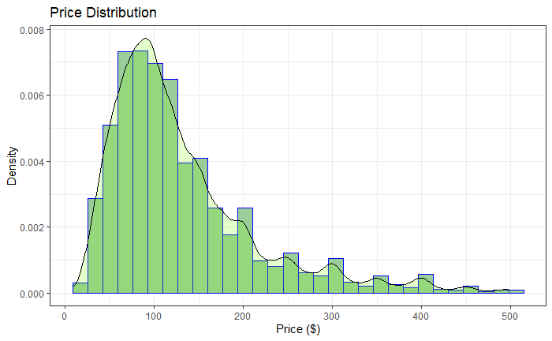

```r
price_distribution = listings %>% filter(price < 500) %>% ggplot(aes(x = price)) +
  geom_histogram(aes(y = ..density..), color = "blue", fill = "darkseagreen3") + geom_density(alpha = .2, fill="chartreuse") + xlab('Price ($)') + ylab('Density') + ggtitle('Price Distribution') + theme_bw()
price_distribution
```

As can be seen, the distribution is right skewed meaning that the very few listings priced at very high price influence the distribution shape whereas we can see from the plot that most of the listings is centered around $100 and is under $200. From the summary info before, we know that the median is $114 and mean is $189 which is pretty affordable keeping in mind that this is the capital city of the United States. Effects from COVID-19 probably influenced the cost to be lower than what’s considered normal in a metropolitan area. The limitation of the dataset is that only the past 12 months were provided by the organization so I was limited to doing analysis for the current year of April 2020 - April 2021.

Which Room type has the most listings?

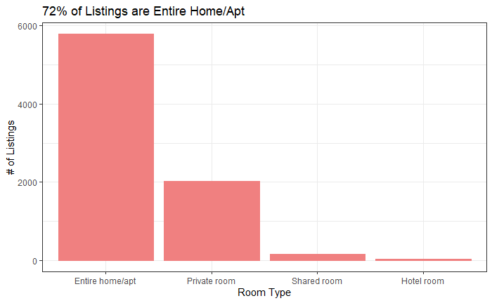

```r
room_type_count =listings %>% group_by(room_type) %>% summarise(count = sum(n())) %>% arrange(desc(count)) %>% ggplot(aes(x=reorder(room_type, -count), y=count)) + geom_bar(stat='identity', color = 'lightcoral', fill = 'lightcoral') + ylab('# of Listings') + xlab('Room Type') + ggtitle('72% of Listings are Entire Home/Apt') + theme_bw()
room_type_count
```

Let’s look at the Property/Room Type and how it affects price distribution:

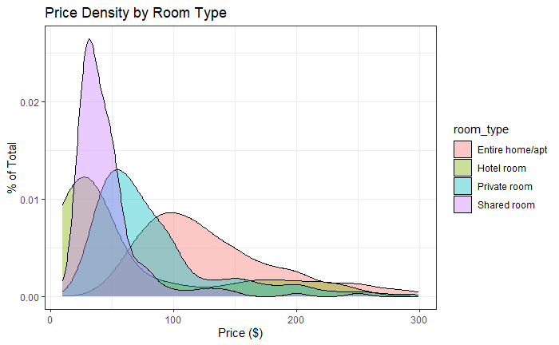

```r
price_density_room_type = listings %>% filter(price < 300) %>% ggplot(aes(x=price, group = room_type, fill=room_type)) + geom_density(adjust = 1.5, alpha =.4) + xlab('Price ($)') + ylab('% of Total') + ggtitle('Price Density by Room Type') + theme_bw()
price_density_room_type
```

What is the average price per Neighborhood?

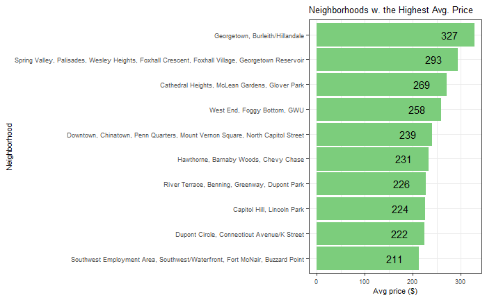

```r
high_10_price = listings %>% group_by(neighbourhood) %>% summarise(avg_price = mean(price)) %>% arrange(desc(avg_price)) %>% top_n(10)
high_10_price %>%
  ggplot(aes(x=reorder(neighbourhood, avg_price), y=avg_price)) + geom_bar(stat='identity', color = 'palegreen3', fill = 'palegreen3') + coord_flip() + geom_text(aes(label= round(avg_price)), nudge_y=-50, color='black') + ylab('Avg price ($)') + xlab('Neighborhood') + ggtitle('Neighborhoods w. the Highest Avg. Price') + theme_bw() + theme(text=element_text(size = 8))
```

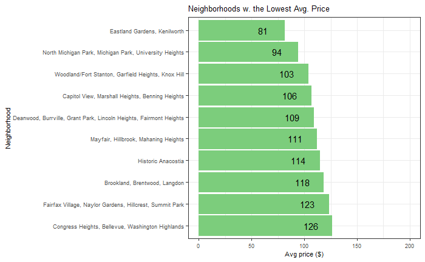

```r
low_10_price = listings %>% group_by(neighbourhood) %>% summarise(avg_price = mean(price)) %>% slice_min(avg_price, n =10)

low_10_price %>%
  ggplot(aes(x=reorder(neighbourhood, -avg_price), y=avg_price)) + geom_bar(stat='identity', color = 'palegreen3', fill = 'palegreen3') + scale_y_continuous(limits = c(0, 200)) + coord_flip() + geom_text(aes(label= round(avg_price)), nudge_y=-20, color='black') + ylab('Avg price ($)') + xlab('Neighborhood') + ggtitle('Neighborhoods w. the Lowest Avg. Price') + theme_bw() + theme(text=element_text(size = 8))
```

Since the dataset was missing Neighborhood Group information making it difficult to group the 39 neighborhoods present in the data to show trends in the landscape, I searched and found that Washington, D.C groups its neighborhoods in 8 wards, historically. So I first populated the neighborhoods data file containing the 39 neighborhood names with the corresponding ward based off of Wikipedia and publicly available city information. Then I joined it to the main listings dataset to capture the ward/neighborhood grouping factor as a new field.

```r
neighbourhoods = read.csv('./neighbourhoods.csv')
head(neighbourhoods, 2)
```

|  | ward | neighbourhood |
| --- | --- | --- |
| 1 | Ward 4 | Brightwood Park, Crestwood, Petworth |
| 2 | Ward 5 | Brookland, Brentwood, Langdon |

```r
listings = inner_join(listings, neighbourhoods, by = 'neighbourhood')
head(listings, 2)
```

|  | id | name | host_id | neighbourhood | latitude | longitude | room_type | price | number_of_reviews | host_listings | availability | rating | ward |
| --- | --- | --- | --- | --- | --- | --- | --- | --- | --- | --- | --- | --- | --- |
| 1 | 3686 | Vita's Hideaway | 4645 | Historic Anacostia | 38.86339 | -76.98889 | Private room | 55 | 75 | 2 | 363 | 92 | Ward 8 |
| 2 | 3943 | Historic Rowhouse Near Monuments | 5059 | Edgewood, Bloomingdale, Truxton Circle, Eckington | 38.91195 | -77.00456 | Private room | 70 | 429 | 2 | 365 | 96 | Ward 5 |

Now that we have ward info - a way to group the neighborhoods, let’s see the average price by the ward:

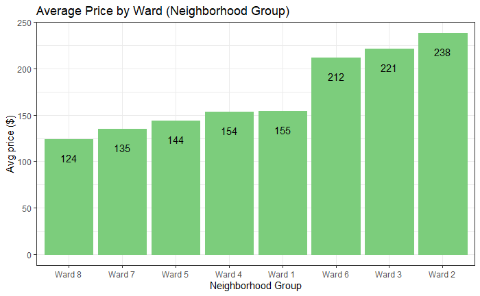

```r
ward_avg_price = listings %>% group_by(ward) %>% summarise(avg_price = mean(price)) %>% arrange(avg_price)
ward_avg_price %>%
  ggplot(aes(x=reorder(ward, avg_price), y=avg_price)) + geom_bar(stat='identity', color = 'palegreen3', fill = 'palegreen3')  + geom_text(aes(label= round(avg_price)), nudge_y=-20, color='black') + ylab('Avg price ($)') + xlab('Neighborhood Group') + ggtitle('Average Price by Ward (Neighborhood Group)') + theme_bw()
```

From reading about D.C and knowing a little about certain parts of the city, this makes sense that the closer you get to the Downtown area(Ward 2) with the historic monuments and landmarks(Ward 2) along with affluent residential area(Ward 3) and government buildings(Ward 6) where most of the large events and public gatherings take place the pricier the listings get. On the other hand, Wards 5,7,8 are located furthest away from the Downtown area and can be shown to have the lowest average price per day from the graph above.

Let’s see how much of the Market Size each Ward makes up - by multiplying the available days per year of each listing with its price and summing up by the ward:

```r
listings = listings %>% mutate(availability_price = availability * price)

market_size = sum(listings$availability_price)

market_size_by_ward = listings %>% group_by(ward) %>% summarise(ward_market_size = sum(availability_price), ward_ratio = round(ward_market_size/market_size*100)) %>% arrange(desc(ward_market_size))

market_size_by_ward
```

| ward | ward_market_size | ward_ratio |
| --- | --- | --- |
| Ward 2 | 75210500 | 35 |
| Ward 6 | 57202866 | 27 |
| Ward 1 | 26718043 | 13 |
| Ward 5 | 21817015 | 10 |
| Ward 4 | 12051586 | 6 |
| Ward 3 | 9692534 | 5 |
| Ward 7 | 5649038 | 3 |
| Ward 8 | 4380158 | 2 |

Let’s visualize it:

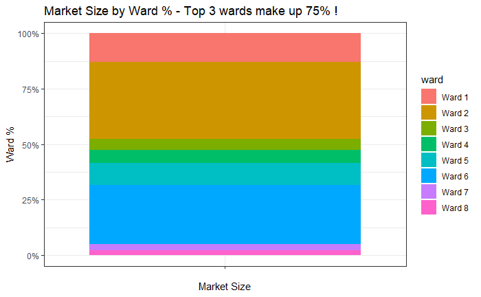

```r
market_size_by_ward %>% ggplot(aes(fill = ward, y=ward_ratio, x='')) +
    geom_bar(position="fill", stat="identity") + scale_y_continuous(labels=scales::percent) + ylab('Ward %') + xlab('Market Size') + ggtitle('Market Size by Ward % - Top 3 wards make up 75% !') + theme_bw()
```

It’s interesting to see from the Market Size % stacked Barchart that the top 3 wards - Wards 2, 6, and 1 - contribute 75% of the total Market size. These same 3 wards are located closest to the Downtown area of Washington D.C supporting the earlier trend seen in Average Price by Neighborhood Group Barplot.

Let’s see if this emerging trend is related to Reviews - there are 2 kinds of review fields - 1st being number of reviews-to-date for the listing and the 2nd being reviews the listing has in the last 12 months, latter of which I missed to capture from the listings_detailed dataset earlier so I am going to capture it now and join it to our main dataset to add to the analysis.

This is actually quite important as the reviews-to-date field will represent how actively occupied and popular the listing has been ever since it has been active on the market which could be for years. Whereas for the reviews-in-the-last-12-months field will be more indicative of how likely the listing is currently to be in demand for bookings. Therefore the reviews field for the last 12 months will be used to compute the likelihood of listings to be in demand when compared to other listings.

```r
last_yr_reviews = listings_detailed %>% select('id', 'number_of_reviews_ltm')
listings = inner_join(listings, last_yr_reviews, by = 'id')
listings
```

| id | name | host_id | neighbourhood | latitude | longitude | room_type | price | number_of_reviews | host_listings | availability | rating | ward | availability_price | number_of_reviews_ltm |
| --- | --- | --- | --- | --- | --- | --- | --- | --- | --- | --- | --- | --- | --- | --- |
| 3686 | Vita's Hideaway | 4645 | Historic Anacostia | 38.86339 | -76.98889 | Private room | 55 | 75 | 2 | 363 | 92 | Ward 8 | 19965 | 3 |
| 3943 | Historic Rowhouse Near Monuments | 5059 | Edgewood, Bloomingdale, Truxton Circle, Eckington | 38.91195 | -77.00456 | Private room | 70 | 429 | 2 | 365 | 96 | Ward 5 | 25550 | 0 |
| 4197 | Bedroom in DC 2 blocks to Metro | 5061 | Capitol Hill, Lincoln Park | 38.88719 | -76.99472 | Private room | 80 | 45 | 2 | 324 | 97 | Ward 6 | 25920 | 0 |
| 4529 | Bertina's House Part One | 5803 | Eastland Gardens, Kenilworth | 38.90585 | -76.94469 | Private room | 54 | 102 | 1 | 140 | 93 | Ward 7 | 7560 | 0 |
| 4967 | DC, Near Metro | 7086 | Ivy City, Arboretum, Trinidad, Carver Langston | 38.91217 | -76.99249 | Private room | 99 | 31 | 3 | 295 | 95 | Ward 5 | 29205 | 0 |
| 5589 | Cozy apt in Adams Morgan | 6527 | Kalorama Heights, Adams Morgan, Lanier Heights | 38.91887 | -77.04008 | Entire home/apt | 73 | 95 | 2 | 123 | 91 | Ward 1 | 8979 | 0 |
| 7103 | Best of Washington - Great neighborhood, parking | 17633 | Spring Valley, Palisades, Wesley Heights, Foxhall Crescent, Foxhall Village, Georgetown Reservoir | 38.91999 | -77.09774 | Entire home/apt | 99 | 88 | 30 | 197 | 97 | Ward 3 | 19503 | 1 |
| 9097 | Adams Morgan Charm | 6527 | Kalorama Heights, Adams Morgan, Lanier Heights | 38.91966 | -77.04306 | Private room | 42 | 112 | 2 | 26 | 97 | Ward 1 | 1092 | 0 |
| 9641 | Sophisticated Logan Circle Loft | 32067 | Dupont Circle, Connecticut Avenue/K Street | 38.90927 | -77.03471 | Entire home/apt | 185 | 154 | 2 | 67 | 95 | Ward 2 | 12395 | 1 |
| 11785 | Sanctuary near Cathedral | 32015 | Cathedral Heights, McLean Gardens, Glover Park | 38.92622 | -77.07591 | Entire home/apt | 127 | 397 | 4 | 347 | 92 | Ward 3 | 44069 | 9 |

[output cut: 990 more lines]

Now that we have both types of review counts, let’s first see the Reviews-to-date for listings by each Neighborhood Group (ward):

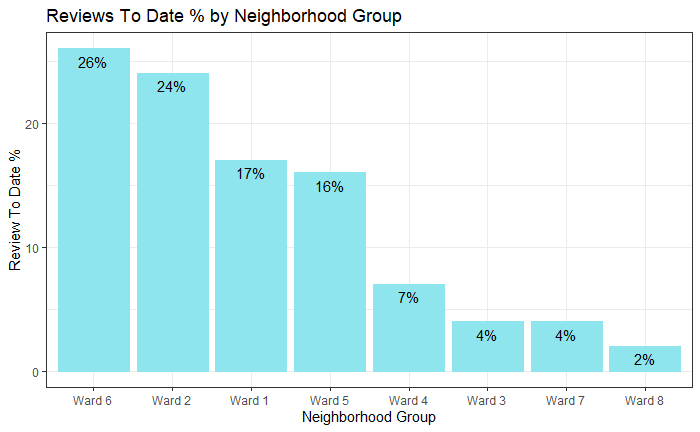

```r
total_reviews = sum(listings$number_of_reviews)
reviews_by_ward = listings %>% group_by(ward) %>% summarise(ward_reviews = sum(number_of_reviews), ward_review_ratio=round(ward_reviews/total_reviews*100)) %>% arrange(desc(ward_reviews))

reviews_by_ward %>%
  ggplot(aes(x=reorder(ward, -ward_review_ratio), y=ward_review_ratio)) + geom_bar(stat='identity', color = 'cadetblue2', fill = 'cadetblue2')  + geom_text(aes(label= paste0(ward_review_ratio, '%')), nudge_y= -1, color='black') + ylab('Review To Date %') + xlab('Neighborhood Group') + ggtitle('Reviews To Date % by Neighborhood Group') + theme_bw()
```

The same top 3 wards(Wards 6,2,1) that made up 75% of the total Market Size also account for 67% of All Reviews to date. This makes perfect sense as one would naturally expect most of the reviews to come from 3/4ths of the Market.

How about Ratings? - since there is minimal and insignificant difference among the Neighborhood Groups, we will not explore further.

```r
ratings_by_ward = listings %>% filter(!is.na(rating)) %>% group_by(ward) %>% summarise(ward_rating = mean(rating)) %>% arrange(desc(ward_rating))
ratings_by_ward
```

| ward | ward_rating |
| --- | --- |
| Ward 6 | 95.71569 |
| Ward 5 | 95.06214 |
| Ward 4 | 95.05378 |
| Ward 1 | 95.02839 |
| Ward 3 | 94.75704 |
| Ward 2 | 94.22362 |
| Ward 7 | 94.15901 |
| Ward 8 | 93.45198 |

Let’s see the trend for the Reviews of last 12 months by Neighborhood Group:

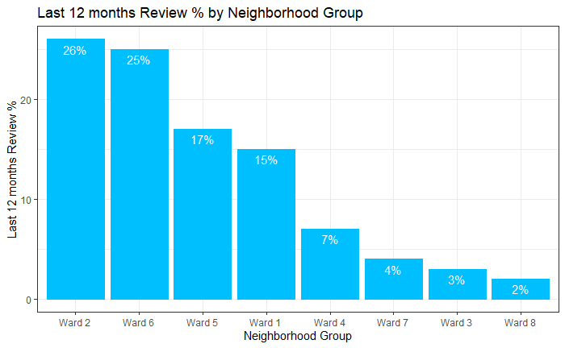

```r
total_reviews_ltm = sum(listings$number_of_reviews_ltm)

reviews_ltm_by_ward = listings %>% group_by(ward) %>% summarise(ward_reviews_ltm = sum(number_of_reviews_ltm), ward_review_ltm_ratio=round(ward_reviews_ltm/total_reviews_ltm*100)) %>% arrange(desc(ward_reviews_ltm))

reviews_ltm_by_ward %>%
  ggplot(aes(x=reorder(ward, -ward_review_ltm_ratio), y=ward_review_ltm_ratio)) + geom_bar(stat='identity', color = 'deepskyblue', fill = 'deepskyblue')  + geom_text(aes(label= paste0(ward_review_ltm_ratio, '%')), nudge_y= -1, color='white') + ylab('Last 12 months Review %') + xlab('Neighborhood Group') + ggtitle('Last 12 months Review % by Neighborhood Group') + theme_bw()
```

The last 12 months Review % shows that the most current reviews trends haven’t changed much from the Reviews To Date as the top 4 wards have stayed the same contributing about the same % of the Reviews. Ward 5 has gone up a place by owning 2% more reviews in the last year compared to Ward 1 so this is good to know from a potential host standpoint.

Now that we have looked at the trends in Reviews, I can finally answer my 1st question of interest: As a potential guest, Ward 1 and Ward 5 (as a second option) seems to offer the most affordable price on average (potential savings of $83 per day) while being considerably frequently reviewed and located closest to the ward with the downtown area with all the historic landmarks. Ward 1 and Ward 5 as a backup option also makes up a sizeable portion of the Market size which means potential guests will have enough variety listings to choose from. So here are the Neighborhoods in Ward 1 and Ward 5 that you can search to get a sweet deal showing their average daily price:

```r
unique(listings$ward)
```

```
[1] "Ward 8"  "Ward 5"  "Ward 6"  "Ward 7"  "Ward 1 " "Ward 3"  "Ward 2"  "Ward 4"
```

```r
listings = listings %>% mutate(ward = gsub("Ward 1 ", "Ward 1", ward))
```

Ward 1 (Best option for guest - closer to downtown):

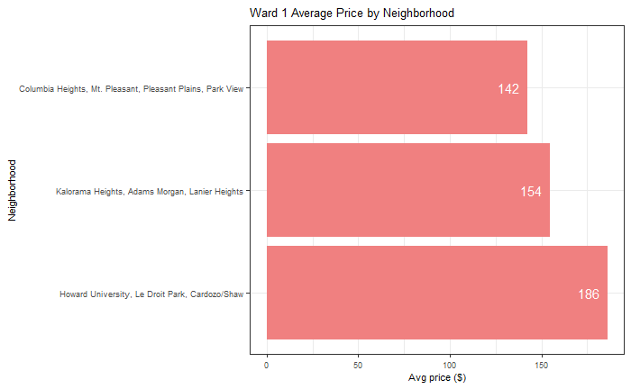

```r
listings %>% filter(ward == "Ward 1") %>% group_by(neighbourhood) %>% summarise(avg_price = mean(price)) %>% arrange(avg_price) %>%
  ggplot(aes(x=reorder(neighbourhood, -avg_price), y=avg_price)) + geom_bar(stat='identity', color = 'lightcoral', fill = 'lightcoral') +  coord_flip() + geom_text(aes(label= round(avg_price)), nudge_y=-10, color='white') + ylab('Avg price ($)') + xlab('Neighborhood') + ggtitle('Ward 1 Average Price by Neighborhood') + theme_bw() + theme(text=element_text(size = 8))
```

```r
NA
NA
```

Ward 5 (Alternative Better option for guest):

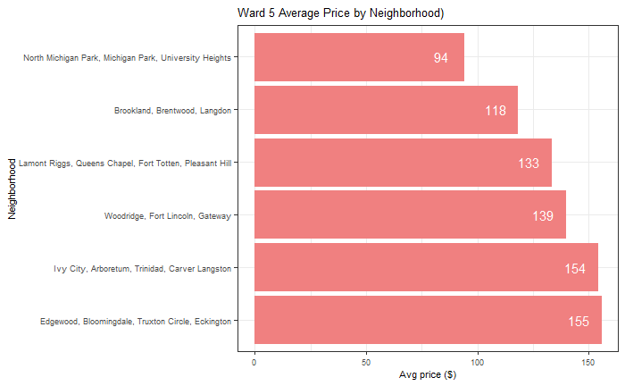

```r
listings %>% filter(ward == "Ward 5") %>% group_by(neighbourhood) %>% summarise(avg_price = mean(price)) %>% arrange(avg_price) %>%
  ggplot(aes(x=reorder(neighbourhood, -avg_price), y=avg_price)) + geom_bar(stat='identity', color = 'lightcoral', fill = 'lightcoral') +  coord_flip() + geom_text(aes(label= round(avg_price)), nudge_y=-10, color='white') + ylab('Avg price ($)') + xlab('Neighborhood') + ggtitle('Ward 5 Average Price by Neighborhood)') + theme_bw() + theme(text=element_text(size = 8))
```

Let’s determine where the likelihood of a listing is to be more in demand by taking the ratio between the last 12 month current Reviews and its availability by neighborhood group (ward). Using the last 12 month review count as an indicator of likelihood of occupancy and the listing available days as a factor of meeting the market demand:

```r
total_reviews_ltm = sum(listings$number_of_reviews_ltm)
total_availability = sum(listings$availability)
likelihood = listings %>% group_by(ward) %>% summarise(ward_reviews_ltm = sum(number_of_reviews_ltm), ward_availability = sum(availability), reviews_per_availability = ward_reviews_ltm/ward_availability) %>% arrange(desc(reviews_per_availability))
likelihood
```

| ward | ward_reviews_ltm | ward_availability | reviews_per_availability |
| --- | --- | --- | --- |
| Ward 5 | 6515 | 142516 | 0.04571417 |
| Ward 7 | 1613 | 46273 | 0.03485834 |
| Ward 1 | 5778 | 168607 | 0.03426904 |
| Ward 6 | 9802 | 302048 | 0.03245180 |
| Ward 2 | 9856 | 313229 | 0.03146580 |
| Ward 4 | 2690 | 91984 | 0.02924422 |
| Ward 8 | 911 | 32888 | 0.02770007 |
| Ward 3 | 1292 | 50347 | 0.02566191 |

Here I can address the 2nd Question of my interest: Ward 5 and 1 would be the wards I would look into potentially put a listing because they have the highest likelihood for demand currently and they are good pick for people who are looking for affordable options compared to Downtown area listings which are more expensive. Ward 7 isn’t recommended because it only makes up 3% of market size having less information to make an investment decision. However on the other hand I guess it could be an option due to less competition so we may keep an eye on it.

Visualization:

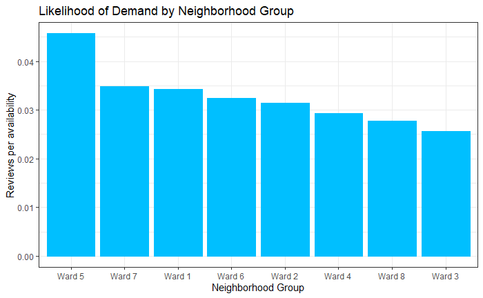

```r
listings %>% group_by(ward) %>% summarise(ward_reviews_ltm = sum(number_of_reviews_ltm), ward_availability = sum(availability), reviews_per_availability = ward_reviews_ltm/ward_availability) %>% arrange(desc(reviews_per_availability)) %>%

  ggplot(aes(x=reorder(ward, -reviews_per_availability ), y=reviews_per_availability)) + geom_bar(stat='identity', color = 'deepskyblue', fill = 'deepskyblue') + ylab('Reviews per availability') + xlab('Neighborhood Group') + ggtitle('Likelihood of Demand by Neighborhood Group') + theme_bw()
```

```r
  # ggplot(aes(x=reorder(ward, -reviews_per_availability), y=reviews_per_availability)) + geom_bar(stat='identity', color = 'deepskyblue', fill = 'deepskyblue') + ylab('Reviews per availability') + xlab('Neighborhood Group') + ggtitle('Likelihood of Demand by Neighborhood Group) + theme_bw()
```

Next Steps:

- Obtain data from previous years for better comparison and trends over the years
- Build a predictive model to apply to new data
- Complete the Shiny app with interactive Map features

```r
listings_shiny = listings
write.csv(listings_shiny,"C:/Users/oyb50/Documents/Augi/NYC DS Academy/Bootcamp/Projects/Shiny Project/Airbnb-Shiny/listings_shiny.csv", row.names = FALSE)
```